# Tutorial 1: Probabilidad con R

Estadística I — Matemáticas Aplicadas y Computación

Dra. Elizabeth Martínez Gómez

En este tutorial utilizaremos **R para explorar distribuciones de probabilidad, calcular probabilidades y visualizar su significado**.

El objetivo no es aprender comandos de R de manera aislada. La idea es desarrollar una rutina de trabajo:

$$\boxed{\text{situación}\;\longrightarrow\;\text{variable
aleatoria}\;\longrightarrow\;\text{distribución}\;\longrightarrow\;\text{evento}\;\longrightarrow\;\text{probabilidad}\;\longrightarrow\;R}$$

En particular, aprenderás a:

- distinguir variables aleatorias **discretas y continuas**;
- reconocer algunas distribuciones de uso frecuente;
- identificar sus parámetros;
- calcular probabilidades exactas, acumuladas, de cola y entre dos valores;
- obtener cuantiles;
- representar gráficamente distribuciones y regiones de probabilidad;
- interpretar el resultado obtenido con R.

> **Idea central:** primero decide matemáticamente **qué probabilidad quieres calcular** y después utiliza R para obtenerla y comprobarla.

# 1. Una distribución de probabilidad: ¿qué debemos reconocer?

Una **variable aleatoria** asigna valores numéricos a los resultados de un experimento aleatorio.

Ejemplos:

- $X$ = número de piezas defectuosas en una muestra;
- $X$ = número de llamadas recibidas durante una hora;
- $X$ = tiempo de reparación de un automóvil;
- $X$ = vida útil de una lámpara.

La **distribución de probabilidad** describe cómo se distribuye la probabilidad entre los posibles valores de la variable aleatoria.

## 1.1 Discreta o continua

Una variable aleatoria **discreta** toma valores aislados. Por ejemplo, un número de llamadas puede ser 0, 1, 2, 3, etc.

Su función de masa satisface:

$$p_X(x)=P(X=x),$$

$$p_X(x)\geq 0,
\qquad
\sum_xp_X(x)=1$$

Una variable aleatoria **continua** puede tomar cualquier valor dentro de un intervalo. Su distribución se describe mediante una densidad $f_X(x)$, que debe satisfacer:

$$f_X(x)\geq0,
\qquad
\int_{-\infty}^{\infty}f_X(x)\,dx=1$$

Las probabilidades son áreas:

$$P(a<X<b)=\int_a^b f_X(x)\,dx$$

Por ello, para una variable continua:

$$P(X=a)=0$$

## 1.3 Eventos, unión, intersección e independencia

Antes de elegir una distribución, también necesitamos traducir correctamente el enunciado a un **evento**.

Para dos eventos $A$ y $B$:

$$P(A\cup B)=P(A)+P(B)-P(A\cap B)$$

Si son mutuamente excluyentes,

$$A\cap B=\varnothing
\quad\Longrightarrow\quad
P(A\cap B)=0$$

Si son independientes,

$$\boxed{P(A\cap B)=P(A)P(B)}$$

La probabilidad condicional se define como

$$P(A\mid B)=\frac{P(A\cap B)}{P(B)},\qquad P(B)>0$$

Aquí solo la repasaremos como herramienta básica. La estudiaremos con mayor detalle en la distribución exponencial, donde aparece la propiedad de falta de memoria.

### Actividad 1B — Reconoce la relación entre eventos

Supón que $P(A)=0.40$, $P(B)=0.30$ y $P(A\cap B)=0.12$.

1. Comprueba si $A$ y $B$ son independientes.
2. Calcula $P(A\mid B)$.
3. Explica qué información aporta la condición $B$ sobre la probabilidad de $A$.

**No uses R todavía.** El objetivo es practicar la traducción matemática.

## 1.4 ¿Una función puede ser una distribución de probabilidad?

Cuando te entregan una función y te preguntan si puede representar una distribución, no basta con observar su forma. Debes verificar las condiciones matemáticas.

Por ejemplo, para una función de masa discreta definida por

$$p_X(x)=\frac{x+1}{6},\qquad x=0,1,2,$$

comprobamos que las probabilidades son no negativas y que

$$\sum_{x=0}^{2}\frac{x+1}{6}=1$$

Por tanto, sí puede ser una función de masa de probabilidad.

Para una densidad continua, por ejemplo

$$f_X(x)=2x,\qquad 0<x<1,$$

se verifica

$$f_X(x)\geq0$$

y

$$\int_0^1 2x\,dx=1$$

La idea que debes conservar es:

$$\boxed{\text{discreta}\rightarrow\text{suma}=1\qquad
\text{continua}\rightarrow\text{integral}=1}$$

Esta comprobación será necesaria cuando trabajes con funciones propuestas como posibles distribuciones.

# 2. El lenguaje de las distribuciones en R

R utiliza una estructura muy sencilla para muchas distribuciones.

| Prefijo | Función | Significado |
| --- | --- | --- |
| `d` | densidad / masa | En discreta: $P(X=x)$; en continua: $f_X(x)$ |
| `p` | probabilidad acumulada | $P(X\leq x)$ |
| `q` | cuantil | Encuentra $x$ a partir de una probabilidad |
| `r` | aleatoria | Genera observaciones de la distribución |

Por ejemplo, para la normal:

```r
dnorm(0)
```

```
## [1] 0.3989423
```

```r
pnorm(0)
```

```
## [1] 0.5
```

```r
qnorm(0.975)
```

```
## [1] 1.959964
```

```r
rnorm(5)
```

```
## [1]  0.71399412  1.19760271 -3.32420125  0.07803591  0.14233551
```

En este tutorial nos interesan principalmente `d`, `p` y `q`.

> **Atención:** en una distribución continua, `dnorm(x)` no calcula $P(X=x)$. Devuelve la **densidad** en $x$. Las probabilidades se obtienen mediante áreas, y R las calcula con `pnorm()`.

## 2.1 Traducir una pregunta a R

Antes de escribir un comando, completa mentalmente estas cuatro preguntas:

1. ¿Cuál es la variable aleatoria?
2. ¿Qué distribución tiene?
3. ¿Cuáles son sus parámetros?
4. ¿Qué evento representa la pregunta?

Por ejemplo:

> Una variable $X\sim Binomial(20,0.10)$. ¿Cuál es la probabilidad de obtener a lo más 3 éxitos?

La traducción es:

$$X\sim Binomial(20,0.10)$$

$$P(X\leq3)$$

Entonces usamos:

```r
pbinom(3, size = 20, prob = 0.10)
```

```
## [1] 0.8670467
```

# 3. Distribuciones discretas

## 3.1 Bernoulli: un ensayo, dos resultados

La distribución de Bernoulli describe un solo ensayo con dos resultados: éxito y fracaso.

Si la probabilidad de éxito es $p$, entonces:

$$X\sim Bernoulli(p),$$

con

$$P(X=1)=p,
\qquad
P(X=0)=1-p$$

En R podemos calcular:

```r
p <- 0.30

p0 <- dbinom(0, size = 1, prob = p)
p1 <- dbinom(1, size = 1, prob = p)

c(P_X0 = p0, P_X1 = p1)
```

```
## P_X0 P_X1
##  0.7  0.3
```

Observa que la Bernoulli es la base conceptual de la distribución binomial.

## 3.2 Binomial: contar éxitos

La distribución binomial modela el número de éxitos en $n$ ensayos cuando:

1. hay un número fijo $n$ de ensayos;
2. cada ensayo tiene dos resultados posibles;
3. la probabilidad de éxito $p$ es constante;
4. los ensayos son independientes.

Entonces:

$$X\sim Binomial(n,p)$$

Su función de masa es:

$$P(X=x)=\binom{n}{x}p^x(1-p)^{n-x}$$

### Ejemplo

Una máquina produce piezas y la probabilidad de que una pieza sea defectuosa es $0.10$. Se inspeccionan 20 piezas.

Sea

$$X=\text{número de piezas defectuosas}$$

Entonces:

$$X\sim Binomial(20,0.10)$$

### Probabilidad exacta

$$P(X=3)$$

```r
n <- 20
p <- 0.10

dbinom(3, size = n, prob = p)
```

```
## [1] 0.1901199
```

### Probabilidad acumulada

$$P(X\leq3)$$

```r
pbinom(3, size = n, prob = p)
```

```
## [1] 0.8670467
```

### Probabilidad de cola derecha

$$P(X>3)$$

Usando el complemento:

$$P(X>3)=1-P(X\leq3)$$

```r
1 - pbinom(3, size = n, prob = p)
```

```
## [1] 0.1329533
```

También podemos usar:

```r
pbinom(3, size = n, prob = p, lower.tail = FALSE)
```

```
## [1] 0.1329533
```

### Probabilidad entre dos valores

Para

$$P(2\leq X\leq5),$$

usamos:

$$P(X\leq5)-P(X\leq1)$$

```r
pbinom(5, size = n, prob = p) -
  pbinom(1, size = n, prob = p)
```

```
## [1] 0.5969999
```

También podemos comprobarlo sumando las probabilidades individuales:

```r
sum(dbinom(2:5, size = n, prob = p))
```

```
## [1] 0.5969999
```

### Visualización

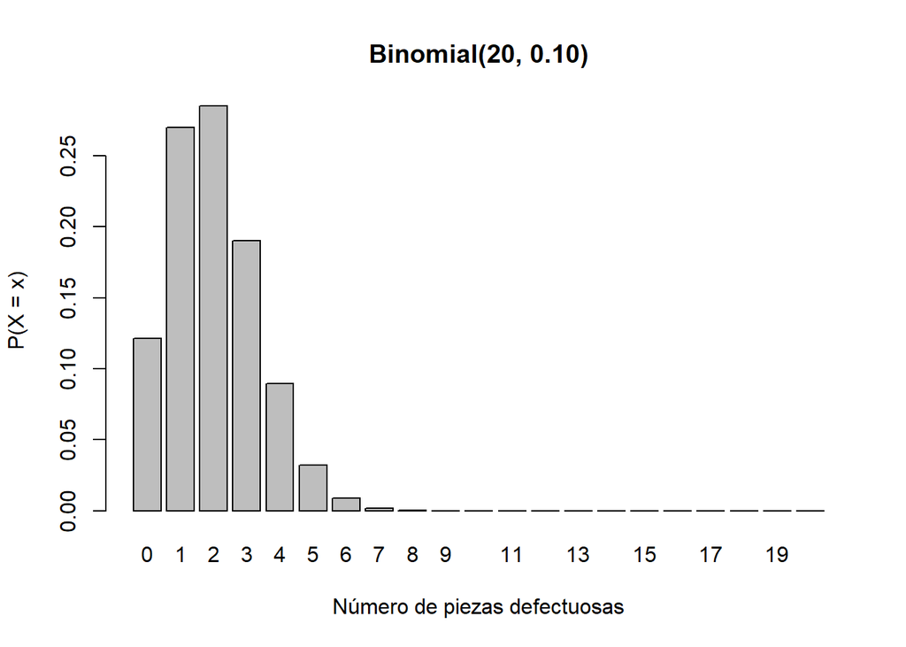

```r
x <- 0:n
prob <- dbinom(x, size = n, prob = p)

barplot(
  prob,
  names.arg = x,
  xlab = "Número de piezas defectuosas",
  ylab = "P(X = x)",
  main = "Binomial(20, 0.10)"
)
```

### Actividad 2 — Explora la binomial

Utiliza $X\sim Binomial(20,0.30)$.

1. Calcula $P(X=5)$.
2. Calcula $P(X\leq5)$.
3. Calcula $P(X>5)$.
4. Calcula $P(4\leq X\leq8)$.
5. Grafica la distribución.
6. Cambia $p$ a 0.50 y vuelve a graficar.
7. Describe qué cambia en la distribución.

> **Antes de ejecutar R:** escribe primero la probabilidad que quieres calcular.

## 3.3 Poisson: contar ocurrencias

La distribución de Poisson es útil para modelar el número de ocurrencias de un evento en un intervalo cuando existe una tasa media $\lambda$ y el modelo de Poisson es apropiado.

$$X\sim Poisson(\lambda)$$

Su función de masa es:

$$P(X=x)=e^{-\lambda}\frac{\lambda^x}{x!}$$

### Ejemplo

Una central recibe en promedio 4 llamadas por minuto.

$$X=\text{número de llamadas en un minuto}$$

$$X\sim Poisson(4)$$

Exactamente 6 llamadas:

```r
lambda <- 4

dpois(6, lambda = lambda)
```

```
## [1] 0.1041956
```

A lo más 6:

```r
ppois(6, lambda = lambda)
```

```
## [1] 0.889326
```

Más de 6:

```r
ppois(6, lambda = lambda, lower.tail = FALSE)
```

```
## [1] 0.110674
```

### Gráfica

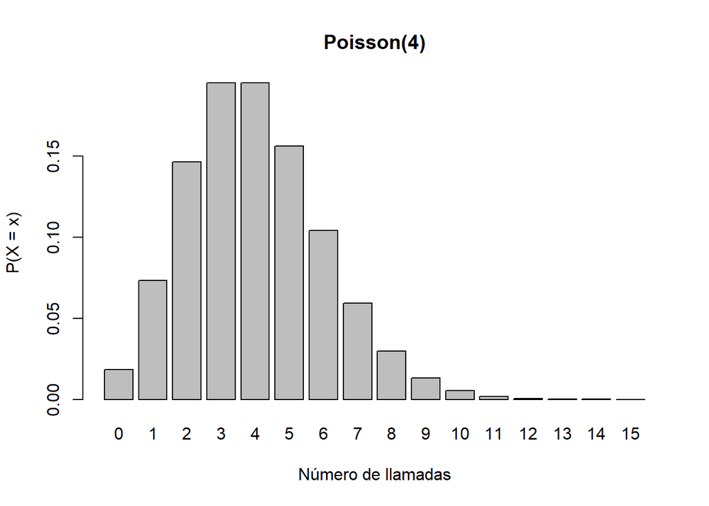

```r
x <- 0:15
prob <- dpois(x, lambda = lambda)

barplot(
  prob,
  names.arg = x,
  xlab = "Número de llamadas",
  ylab = "P(X = x)",
  main = "Poisson(4)"
)
```

### Actividad 3 — Poisson

Para $X\sim Poisson(4)$:

1. Calcula $P(X=2)$.
2. Calcula $P(X\leq2)$.
3. Calcula $P(X>8)$.
4. Calcula $P(3\leq X\leq6)$.
5. Grafica la distribución.
6. Cambia $\lambda$ a 8. ¿Qué observas?

# 4. Distribuciones continuas: la probabilidad como área

En una variable continua, la función de densidad describe la forma de la distribución, pero **la probabilidad es un área**.

$$P(a<X<b)=\int_a^b f_X(x)\,dx$$

Esta idea será central para la uniforme, la normal y la exponencial.

## 4.1 Uniforme continua

Si

$$X\sim U(a,b),$$

su densidad es constante:

$$f_X(x)=\frac{1}{b-a},
\qquad a<x<b$$

### Ejemplo

Sea:

$$X\sim U(420,460)$$

La densidad puede visualizarse así:

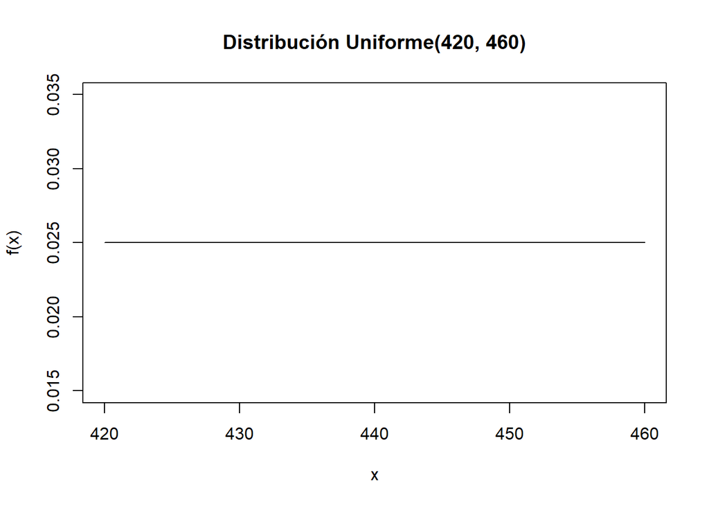

```r
a <- 420
b <- 460

x <- seq(a, b, length.out = 500)

plot(
  x,
  dunif(x, min = a, max = b),
  type = "l",
  xlab = "x",
  ylab = "f(x)",
  main = "Distribución Uniforme(420, 460)"
)
```

### Probabilidad entre dos valores

Por ejemplo:

$$P(425<X<435)$$

En R:

```r
punif(435, min = a, max = b) -
  punif(425, min = a, max = b)
```

```
## [1] 0.25
```

La respuesta representa el área bajo la densidad entre 425 y 435.

### Actividad 4 — Uniforme

Para $X\sim U(420,460)$:

1. Calcula $P(X<430)$.
2. Calcula $P(425<X<435)$.
3. Calcula $P(X>450)$.
4. Representa gráficamente la densidad.
5. Explica por qué la probabilidad puede interpretarse como un área.

# 5. Distribución normal

La distribución normal es una de las distribuciones fundamentales que utilizaremos en Estadística I.

Se escribe:

$$X\sim N(\mu,\sigma^2)$$

Su densidad es:

$$f(x)=
\frac{1}{\sigma\sqrt{2\pi}}
\exp\left[-\frac12\left(\frac{x-\mu}{\sigma}\right)^2\right]$$

En R es importante recordar que `sd` representa la **desviación estándar** $\sigma$, no la varianza $\sigma^2$.

## 5.1 Graficar una normal

Consideremos:

$$X\sim N(70,10^2)$$

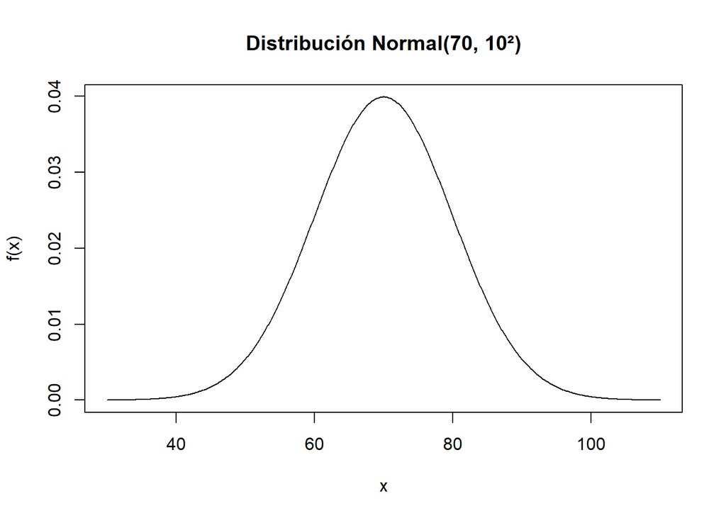

```r
mu <- 70
sigma <- 10

x <- seq(mu - 4*sigma, mu + 4*sigma, length.out = 500)

y <- dnorm(x, mean = mu, sd = sigma)

plot(
  x, y,
  type = "l",
  xlab = "x",
  ylab = "f(x)",
  main = "Distribución Normal(70, 10²)"
)
```

## 5.2 Probabilidad a la izquierda

Queremos:

$$P(X\leq80)$$

```r
pnorm(80, mean = mu, sd = sigma)
```

```
## [1] 0.8413447
```

## 5.3 Probabilidad a la derecha

Queremos:

$$P(X>80)$$

```r
pnorm(80, mean = mu, sd = sigma, lower.tail = FALSE)
```

```
## [1] 0.1586553
```

## 5.4 Probabilidad entre dos valores

Queremos:

$$P(60<X<80)$$

```r
pnorm(80, mean = mu, sd = sigma) -
  pnorm(60, mean = mu, sd = sigma)
```

```
## [1] 0.6826895
```

## 5.5 Visualizar el área

La probabilidad anterior puede verse directamente en la gráfica.

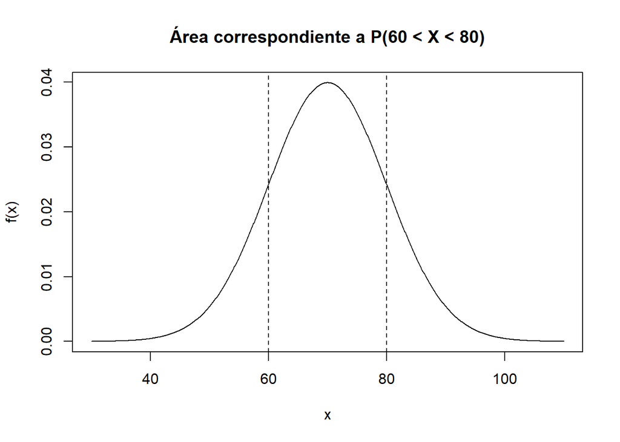

```r
x <- seq(30, 110, length.out = 1000)
y <- dnorm(x, mean = mu, sd = sigma)

plot(
  x, y,
  type = "l",
  xlab = "x",
  ylab = "f(x)",
  main = "Área correspondiente a P(60 < X < 80)"
)

x_area <- seq(60, 80, length.out = 300)
y_area <- dnorm(x_area, mean = mu, sd = sigma)

polygon(
  c(60, x_area, 80),
  c(0, y_area, 0),
  border = NA
)

abline(v = c(60, 80), lty = 2)
```

```r
prob <- pnorm(80, mu, sigma) - pnorm(60, mu, sigma)
prob
```

```
## [1] 0.6826895
```

> **Interpretación:** el número que devuelve `pnorm()` representa el área correspondiente al evento que escribiste matemáticamente.

## 5.6 Estandarización

Si

$$X\sim N(\mu,\sigma^2),$$

podemos transformar a una normal estándar mediante:

$$Z=\frac{X-\mu}{\sigma},
\qquad Z\sim N(0,1)$$

Para $X=80$:

$$z=\frac{80-70}{10}=1$$

```r
z <- (80 - mu) / sigma
z
```

```
## [1] 1
```

Podemos comprobar que:

```r
pnorm(80, mean = mu, sd = sigma)
```

```
## [1] 0.8413447
```

```r
pnorm(1)
```

```
## [1] 0.8413447
```

dan el mismo resultado.

## 5.7 Cuantiles

A veces la pregunta se plantea al revés: conocemos una probabilidad y queremos encontrar el valor de $x$.

Por ejemplo, buscamos $z$ tal que:

$$P(Z\leq z)=0.975$$

En R:

```r
qnorm(0.975)
```

```
## [1] 1.959964
```

Para una normal con media 70 y desviación estándar 10:

$$P(X\leq x)=0.975$$

```r
qnorm(0.975, mean = 70, sd = 10)
```

```
## [1] 89.59964
```

### Actividad 5 — Normal

Sea:

$$X\sim N(45,8^2)$$

1. Calcula $P(X\leq58)$.
2. Calcula $P(X>58)$.
3. Calcula $P(40<X<50)$.
4. Estandariza el valor 58.
5. Verifica mediante R que el cálculo con $X$ y con $Z$ coincide.
6. Grafica la distribución y representa la región correspondiente a $40<X<50$.

# 6. Distribución exponencial: probabilidades y falta de memoria

La distribución exponencial se utiliza para modelar tiempos de espera o tiempos de vida bajo determinadas condiciones.

Si

$$X\sim Exponencial(\lambda),$$

su densidad es:

$$f_X(x)=\lambda e^{-\lambda x},
\qquad x>0$$

Su media es:

$$E(X)=\frac{1}{\lambda}$$

Por tanto, si conocemos la duración media $m$:

$$\lambda=\frac{1}{m}$$

## 6.1 Ejemplo: vida útil de una lámpara

Supongamos que la vida útil de una lámpara tiene una duración media de 0.5 miles de horas.

Entonces:

$$E(X)=0.5$$

y

$$\lambda=\frac{1}{0.5}=2$$

En R podemos trabajar con `rate = 2`.

```r
lambda <- 2
```

### Probabilidad de supervivencia

Queremos:

$$P(X>0.7)$$

```r
pexp(0.7, rate = lambda, lower.tail = FALSE)
```

```
## [1] 0.246597
```

### Tiempo de reemplazo

Queremos encontrar $t$ tal que no más del 10 % de las lámparas fallen antes de ser reemplazadas:

$$P(X\leq t)=0.10$$

Por tanto:

```r
qexp(0.10, rate = lambda)
```

```
## [1] 0.05268026
```

El resultado está en miles de horas.

## 6.2 Probabilidad condicional y falta de memoria

Aquí aparece una propiedad particularmente importante de la distribución exponencial.

Queremos calcular:

$$P(X>1.2\mid X>0.7)$$

Por definición:

$$P(X>1.2\mid X>0.7)
=
\frac{P(X>1.2\cap X>0.7)}{P(X>0.7)}$$

Como

$$\{X>1.2\}\subset\{X>0.7\},$$

la intersección es $\{X>1.2\}$. Entonces:

$$P(X>1.2\mid X>0.7)
=
\frac{P(X>1.2)}{P(X>0.7)}$$

En R:

```r
P12 <- pexp(1.2, rate = lambda, lower.tail = FALSE)
P07 <- pexp(0.7, rate = lambda, lower.tail = FALSE)

P12 / P07
```

```
## [1] 0.3678794
```

Ahora comparemos con:

$$P(X>0.5)$$

```r
pexp(0.5, rate = lambda, lower.tail = FALSE)
```

```
## [1] 0.3678794
```

Para la distribución exponencial se cumple la propiedad de **falta de memoria**:

$$P(X>s+t\mid X>s)=P(X>t)$$

En nuestro ejemplo, como $1.2=0.7+0.5$:

$$P(X>1.2\mid X>0.7)=P(X>0.5)$$

### Actividad 6 — Exponencial

Sea $X\sim Exponencial(2)$, donde el tiempo está medido en miles de horas.

1. Calcula $P(X>0.5)$.
2. Calcula $P(X>1.2\mid X>0.7)$ utilizando la definición de probabilidad condicional.
3. Compara ambos resultados.
4. Explica con tus palabras qué significa la falta de memoria.
5. Grafica la densidad exponencial y describe su forma.

> **Importante:** en este tutorial la probabilidad condicional se estudia de manera explícita únicamente mediante la distribución exponencial, donde tiene una interpretación especialmente significativa.

# 7. Una mirada a dos variables aleatorias

En Estadística I también trabajaremos con distribuciones conjuntas. Aquí solo haremos una introducción para conectar con problemas de dos variables.

Una densidad conjunta $f_{X,Y}(x,y)$ debe satisfacer:

$$f_{X,Y}(x,y)\geq0$$

y

$$\int\!\!\int f_{X,Y}(x,y)\,dx\,dy=1$$

sobre su región de definición.

Una probabilidad sobre una región $A$ se obtiene mediante:

$$P((X,Y)\in A)=
\iint_A f_{X,Y}(x,y)\,dx\,dy$$

Las marginales se obtienen integrando la variable que no interesa:

$$f_X(x)=\int f_{X,Y}(x,y)\,dy,$$

$$f_Y(y)=\int f_{X,Y}(x,y)\,dx$$

## Ejemplo breve

Considera la densidad conjunta:

$$f_{X,Y}(x,y)=x+y,
\qquad 0<x<1,\quad 0<y<1$$

Primero debemos comprobar si realmente es una densidad válida.

```r
# Integral de x+y sobre 0<x<1, 0<y<1
# El cálculo simbólico se puede hacer analíticamente:
# integral_0^1 integral_0^1 (x+y) dx dy = 1
```

Una forma útil de visualizar la densidad es mediante una superficie o un mapa de niveles. Por ejemplo:

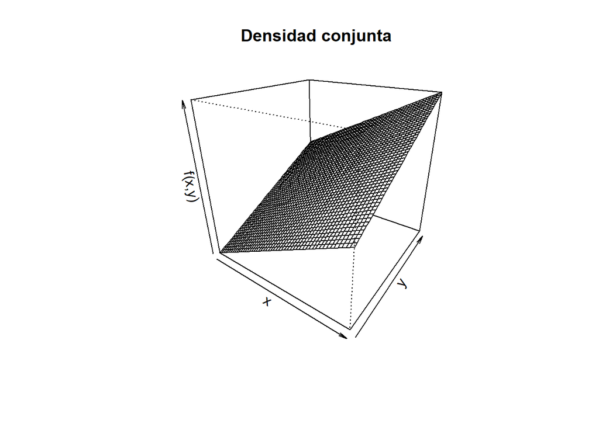

```r
x <- seq(0, 1, length.out = 50)
y <- seq(0, 1, length.out = 50)

z <- outer(x, y, function(x, y) x + y)

persp(
  x, y, z,
  theta = 35,
  phi = 25,
  xlab = "x",
  ylab = "y",
  zlab = "f(x,y)",
  main = "Densidad conjunta"
)
```

### Actividad 7 — Región y marginales

Para la densidad anterior, trabaja con una región **distinta de la que aparece en la tarea**:

$$A=\{(x,y):0<x<2/3,\;1/3<y<2/3\}$$

1. Verifica matemáticamente que es una densidad válida.
2. Calcula $P((X,Y)\in A)$.
3. Obtén $f_X(x)$.
4. Obtén $f_Y(y)$.
5. Describe qué cambia respecto al caso de una sola variable aleatoria.

**Sugerencia:** dibuja primero la región de integración. En dos variables, la región es parte esencial del planteamiento.

> **Observación:** aquí el objetivo no es aprender una nueva familia de distribuciones, sino reconocer que el cálculo de una probabilidad sigue siendo un problema de **área/volumen bajo una función**, ahora en dos dimensiones.

# 8. Actividad integradora: piensa antes de usar R

En cada situación sigue esta secuencia:

$$\boxed{
\text{Variable}\rightarrow
\text{Tipo}\rightarrow
\text{Distribución}\rightarrow
\text{Parámetros}\rightarrow
\text{Evento}\rightarrow
\text{Cálculo en R}
}$$

## Caso A — Conteo

Una máquina produce piezas con probabilidad de defecto $p=0.08$. Se seleccionan 25 piezas independientemente.

Sea $X$ el número de piezas defectuosas.

Calcula:

$$P(X\leq3)$$

Después calcula:

$$P(X>5)$$

**Antes de usar R**, escribe la distribución y las expresiones matemáticas.

## Caso B — Variable continua

El tiempo de atención de un servicio se modela como:

$$X\sim N(30,5^2)$$

Calcula:

$$P(25<X<35)$$

Después grafica la densidad y representa visualmente la región correspondiente.

## Caso C — Tiempo de vida

Una variable $X$ tiene distribución exponencial con media 2 horas.

1. Determina $\lambda$.
2. Calcula $P(X>3)$.
3. Calcula $P(X>5\mid X>2)$.
4. Comprueba la propiedad de falta de memoria.

# 9. ¿Cómo se conecta este tutorial con la tarea?

La tarea no consiste solamente en obtener números con R. En cada problema debes decidir qué herramienta matemática corresponde.

| En la tarea | ¿Qué debes recuperar en este tutorial? |
| --- | --- |
| Problemas 1–2 | Eventos, independencia y traducción matemática de probabilidades |
| Problema 3 | Diferencia entre función de masa y densidad; condiciones de validez |
| Problema 4 | Normal y binomial; planteamiento antes de usar R |
| Problema 5 | Exponencial, cuantiles y probabilidad condicional |
| Problema 6 | Normal estándar, cuantiles y representación de áreas |
| Problema 7 | Densidad conjunta, región de integración y marginales |

> **Importante:** el tutorial utiliza ejemplos distintos de los problemas de la tarea. La finalidad es que aprendas el procedimiento y puedas aplicarlo posteriormente a situaciones nuevas.

# 10. Checklist: ¿ya puedo trabajar con una distribución?

Antes de entregar un ejercicio, verifica:

- Definí la variable aleatoria.
- Determiné si es discreta o continua.
- Identifiqué la distribución.
- Identifiqué sus parámetros.
- Escribí matemáticamente el evento solicitado.
- Decidí si necesito `d`, `p` o `q`.
- Escribí primero la expresión matemática y después el comando de R.
- Interpreté el resultado en el contexto del problema.
- Si la variable es continua, entiendo la probabilidad como un área.
- Si trabajé con una distribución conjunta, identifiqué correctamente la región de integración.

# 11. Puente hacia Estadística I

El manejo de distribuciones de probabilidad será una herramienta fundamental durante Estadística I.

En particular, necesitarás reconocer que una distribución permite describir el comportamiento probabilístico de una variable y calcular probabilidades asociadas a eventos de interés.

En Estadística I se estudiarán posteriormente otras distribuciones y su papel en las distribuciones muestrales y en la inferencia estadística.

La meta de este repaso es que llegues a esos temas con una herramienta fundamental ya recuperada:

$$\boxed{\text{reconocer una distribución y calcular e interpretar sus
probabilidades.}}$$

**Recordatorio final:** R puede hacer el cálculo en una fracción de segundo. Lo importante es que tú puedas explicar **qué está calculando R, por qué esa es la distribución adecuada y qué significa el resultado**.